# Reproducible research with R - Course project 1

## Introduction

It is now possible to collect a large amount of data about personal movement using activity monitoring devices such as a Fitbit, Nike Fuelband, or Jawbone Up. These type of devices are part of the “quantified self” movement – a group of enthusiasts who take measurements about themselves regularly to improve their health, to find patterns in their behavior, or because they are tech geeks. But these data remain under-utilized both because the raw data are hard to obtain and there is a lack of statistical methods and software for processing and interpreting the data.

This assignment makes use of data from a personal activity monitoring device. This device collects data at 5 minute intervals through out the day. The data consists of two months of data from an anonymous individual collected during the months of October and November, 2012 and include the number of steps taken in 5 minute intervals each day.

Over the course of this project, we will examine a number of aspects of this dataset.

## Loading the data

The dataset is stored in the `activity.csv` file in the `Raw data` subdirectory of the project directory. The dataset contains the following variables:

- *steps*: Number of steps taking in a 5-minute interval (missing values are coded as `NA`);
- *date*: The date on which the measurement was taken in YYYY-MM-DD format;
- *interval*: Identifier for the 5-minute interval in which measurement was taken.

```r
activity.data <- read.csv("Raw data/activity.csv")
```

*Note*: Exploratory graphs will be plotted using the `ggplot2` package:

```r
library(ggplot2)
```

## Examining the total number of steps taken per day

For this part, we are ignoring missing values in the dataset.

### Calculating the total number of steps taken per day

Summarizing the numer of steps per day. The `aggregate()` function ignores `NA` values by default.

```r
steps.per.day <- aggregate(steps ~ date, data = activity.data, sum)
```

### Summarize the data in a histogram

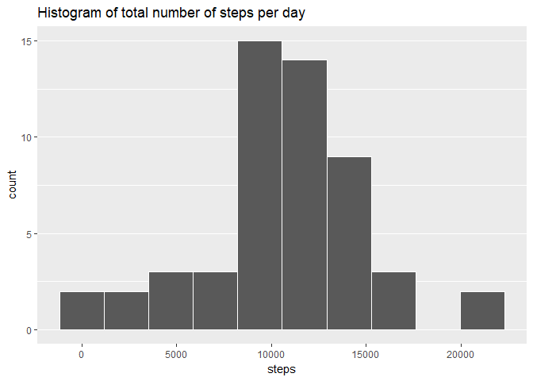

```r
hist1 <- ggplot(data = steps.per.day, aes(steps)) +
  geom_histogram(bins = 10, col = "white") +
  ggtitle("Histogram of total number of steps per day") +
  theme(panel.grid.major.x = element_blank(), panel.grid.minor.x = element_blank())
print(hist1)
```

### Mean and mean total number of steps taken per day

The mean and median values were rounded, to reflect that a number of steps should realistically always be an interger value.

```r
mean.steps.per.day <- round(mean(steps.per.day$steps))
median.steps.per.day <- round(median(steps.per.day$steps))

print(paste("Mean steps per day:", mean.steps.per.day))
```

```
## [1] "Mean steps per day: 10766"
```

```r
print(paste("Median steps per day:", median.steps.per.day))
```

```
## [1] "Median steps per day: 10765"
```

## Investigating avearage daily activity patterns

First, we look at a time series plot of the 5-minute interval (x-axis) and the average number of steps taken, averaged over all days (y-axis) (again averaged for consistency):

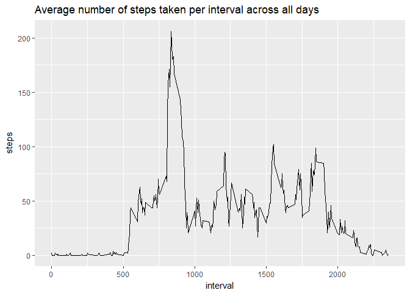

```r
# First calculate the average number of steps per interval
mean.steps.per.interval <- round(aggregate(steps ~ interval, data = activity.data, mean))

# Next, plot the time series using the calculated averages per interval
ggplot(data = mean.steps.per.interval, aes(interval, steps)) +
  geom_line() +
  ggtitle("Average number of steps taken per interval across all days")
```

Next, let’s find the interval which, on average across all days of the dataset, contains the maximum number of steps:

```r
mean.steps.per.interval$interval[which.max(mean.steps.per.interval$steps)]
```

```
## [1] 835
```

In case you were wondering, the corresponding maximal number of steps is:

```r
mean.steps.per.interval$steps[which.max(mean.steps.per.interval$steps)]
```

```
## [1] 206
```

## Imputing missing values

The dataset contains a significant number of missing values:

```r
sum(is.na(activity.data$steps))
```

```
## [1] 2304
```

To examine the impact of these missing values, we will impute these values. Our imputing strategy consists of replacing each missing steps value by the median value for the same interval across all days (excluding the missing values):

```r
# First calculate the median number of steps per interval, across all days
median.steps.per.interval <- aggregate(steps ~ interval, data = activity.data, median)

# The imputed dataset is first defined to equal the non-imputed dataset
activity.data.imputed <- activity.data
# To impute, first identify what rows have missing values:
na.indices <- which(is.na(activity.data.imputed$steps))
# For these rows, replace the steps value by the median steps value across all days for the same interval
activity.data.imputed$steps[na.indices] <-
  median.steps.per.interval$steps[match(activity.data.imputed$interval[na.indices],
                                        median.steps.per.interval$interval)]
```

To examine the impact of imputing, we will compare the histogram of the imputed dataset against the histogram of the original dataset. To create a multipanel ggplot with two different plots, we are using the `gridExtra` package:

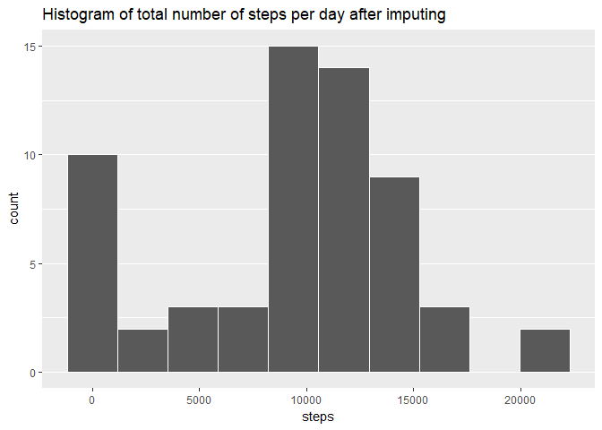

```r
library(gridExtra)

# Calculate the total number of steps per day for the imputed dataset
steps.per.day.imputed <- aggregate(steps ~ date, data = activity.data.imputed, sum)

# Create a ggplot2 histogram
hist2 <- ggplot(data = steps.per.day.imputed, aes(steps)) +
  geom_histogram(bins = 10, col = "white") +
  ggtitle("Histogram of total number of steps per day after imputing") +
  theme(panel.grid.major.x = element_blank(), panel.grid.minor.x = element_blank())
print(hist2)
```

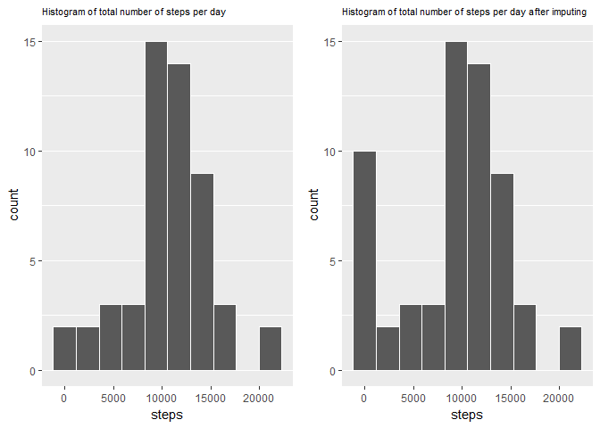

```r
# Print a panel plot comparing the original and imputed histogram
# Some housekeeping to make titles fit properly
hist1 <- hist1 + theme(plot.title = element_text(size=8))
hist2 <- hist2+ theme(plot.title = element_text(size=8))
# Plot the two histograms side by side
grid.arrange(hist1, hist2, ncol=2)
```

The histograms clearly differ. It appears our imputing strategy yields mostly additional “0” step values. Other imputing strategies my result in a different impact on the histogram.

The impact is also evident from the change in average and median values:

```r
mean.steps.per.day.imputed <- round(mean(steps.per.day.imputed$steps))
median.steps.per.day.imputed <- median(steps.per.day.imputed$steps)

print(paste("Mean steps per day:", mean.steps.per.day.imputed))
```

```
## [1] "Mean steps per day: 9504"
```

```r
print(paste("Median steps per day:", median.steps.per.day.imputed))
```

```
## [1] "Median steps per day: 10395"
```

## Difference in activity patterns between weekdays and weekends

We will be working with the imputed dataset for this analysis.

First, we create a new factor variable, reflecting whether the measurement was performed on a weekday or a weekend day.

*Note that we are using the `weekdays()` function, which returns a character vector of names in the locale of the device on which the code is ran - which in this case means* *Dutch*.

```r
activity.data.imputed$daytype <- factor(
  ifelse(weekdays(
    as.Date(as.character(activity.data.imputed$date))
    ) %in% c("zaterdag", "zondag"),
    "weekend",
    "weekday"))
```

Next, we calculate the mean number of steps per interval for weekdays and weekend days, leveraging this new factor variable:

```r
mean.steps.per.interval.and.daytype <- aggregate(steps ~ interval + daytype, data = activity.data.imputed, mean)
```

Finally, we plot a time series plot of average number of steps, for weekdays and weekend days:

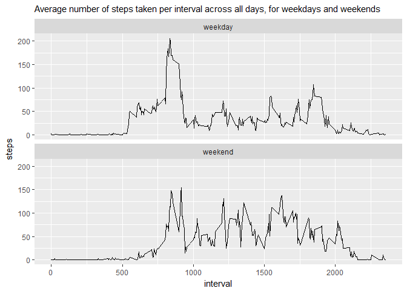

```r
ggplot(data = mean.steps.per.interval.and.daytype, aes(interval, steps)) +
  geom_line() +
  facet_wrap(~ daytype, ncol = 1) +
  theme(plot.title = element_text(size=11)) +
  ggtitle("Average number of steps taken per interval across all days, for weekdays and weekends")
```